###### Modeling Storm Tide Extremes

Download Notebook

# Modeling Storm Tide Extremes

## Setup

The following code loads the environment and makes sure all needed packages are installed. This should be at the start of most Julia scripts.

```
In [156]:
```

```julia
import Pkg
Pkg.activate(@__DIR__)
Pkg.instantiate()
```

```
  Activating project at `~/Teaching/CRA-book/contents/extremes`
```

```
In [157]:
```

```julia
using Random
using StatsBase
using Statistics
using CSV
using Dates
using DataFrames
using DataFramesMeta
using Distributions
using Plots
default(fmt = :png) # the tide gauge data is long, this keeps images a manageable size
using Measures
using StatsPlots
using LaTeXStrings
using Optim
using Turing
```

```
In [158]:
```

```julia
Random.seed!(1)
```

```
TaskLocalRNG()
```

## Introduction

### Load Data

This notebook uses hourly data from the San Francisco, CA tide gauge station, obtained from the [University of Hawaii Sea Level Center](https://uhslc.soest.hawaii.edu/) [(Caldwell et al (2015))](https://doi.org/10.7289/V5V40S7W).

The dataset consists of dates and hours and the tide-gauge measurement, in mm. We’ll load the dataset into a `DataFrame` as in Lab 08.

```
In [159]:
```

```julia
function load_data(fname)
    date_format = DateFormat("yyyy-mm-dd HH:MM:SS")
    # This uses the DataFramesMeta.jl package, which makes it easy to string together commands to load and process data
    df = @chain fname begin
        CSV.File(; delim=',', header=false)
        DataFrame
        rename("Column1" => "year",
                "Column2" => "month",
                "Column3" => "day",
                "Column4" => "hour",
                "Column5" => "gauge")
        # need to reformat the decimal date in the data file
        @transform :datetime = DateTime.(:year, :month, :day, :hour)
        # replace -99999 with missing
        @transform :gauge = ifelse.(abs.(:gauge) .>= 9999, missing, :gauge)
        select(:datetime, :gauge)
    end
    return df
end
```

**1**

Load the file, assuming there is no header.

**2**

Convert to a `DataFrame`.

**3**

Rename columns for ease of access.

**4**

Reformat the decimal datetime provided in the file into a Julia `DateTime`.

**5**

Replace missing data with `missing`.

**6**

Select only the `:datetime` and `:gauge` columns.

```
load_data (generic function with 1 method)
```

```
In [160]:
```

```julia
dat = load_data("data/h551.csv")
first(dat, 6)
```

6×2 DataFrame

Table 1: Processed hourly tide gauge data from San Francisco, from 8/1/1897-1/31/2023.

| Row | datetime DateTime | gauge Int64? |
| --- | --- | --- |
| 1 | 1897-08-01T08:00:00 | 3292 |
| 2 | 1897-08-01T09:00:00 | 3322 |
| 3 | 1897-08-01T10:00:00 | 3139 |
| 4 | 1897-08-01T11:00:00 | 2835 |
| 5 | 1897-08-01T12:00:00 | 2377 |
| 6 | 1897-08-01T13:00:00 | 2012 |

```
In [187]:
```

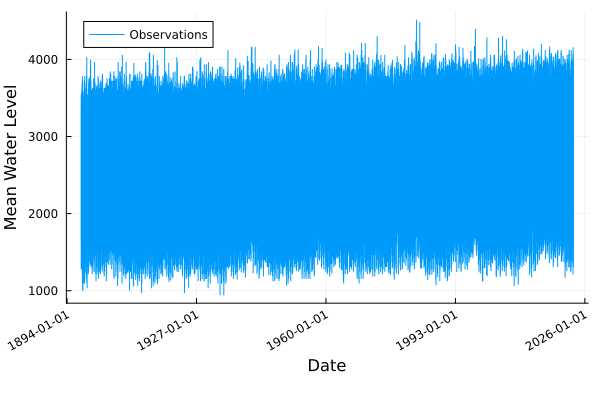

Figure 1: Hourly mean water at the San Francisco tide gauge from 1897-2023.

```julia
tide_plt = @df dat plot(:datetime, :gauge, label="Observations", bottom_margin=9mm)
xaxis!(tide_plt, "Date", xrot=30)
yaxis!(tide_plt, "Mean Water Level")
```

```
In [162]:
```

```julia
ma_length = 366
ma_offset = Int(floor(ma_length/2))
moving_average(series,n) = [mean(@view series[i-n:i+n]) for i in n+1:length(series)-n]
dat_ma = DataFrame(datetime=dat.datetime[ma_offset+1:end-ma_offset], residual=dat.gauge[ma_offset+1:end-ma_offset] .- moving_average(dat.gauge, ma_offset))
```

1099726×2 DataFrame

1099701 rows omitted

| Row | datetime DateTime | residual Float64? |
| --- | --- | --- |
| 1 | 1897-08-08T23:00:00 | 140.967 |
| 2 | 1897-08-09T00:00:00 | 357.455 |
| 3 | 1897-08-09T01:00:00 | 574.109 |
| 4 | 1897-08-09T02:00:00 | 790.847 |
| 5 | 1897-08-09T03:00:00 | 975.095 |
| 6 | 1897-08-09T04:00:00 | 943.264 |
| 7 | 1897-08-09T05:00:00 | 818.689 |
| 8 | 1897-08-09T06:00:00 | 479.869 |
| 9 | 1897-08-09T07:00:00 | -42.6158 |
| 10 | 1897-08-09T08:00:00 | -503.768 |
| 11 | 1897-08-09T09:00:00 | -872.839 |
| 12 | 1897-08-09T10:00:00 | -1118.25 |
| 13 | 1897-08-09T11:00:00 | -1269.75 |
| ⋮ | ⋮ | ⋮ |
| 1099715 | 2023-01-23T21:00:00 | 925.384 |
| 1099716 | 2023-01-23T22:00:00 | 563.422 |
| 1099717 | 2023-01-23T23:00:00 | -46.0163 |
| 1099718 | 2023-01-24T00:00:00 | -656.632 |
| 1099719 | 2023-01-24T01:00:00 | -1119.84 |
| 1099720 | 2023-01-24T02:00:00 | -1397.12 |
| 1099721 | 2023-01-24T03:00:00 | -1425.0 |
| 1099722 | 2023-01-24T04:00:00 | -1289.18 |
| 1099723 | 2023-01-24T05:00:00 | -961.886 |
| 1099724 | 2023-01-24T06:00:00 | -540.733 |
| 1099725 | 2023-01-24T07:00:00 | -120.428 |
| 1099726 | 2023-01-24T08:00:00 | 228.251 |

Plotting this detrended series, we can hopefully see that the data has no long-term trend.

```
In [163]:
```

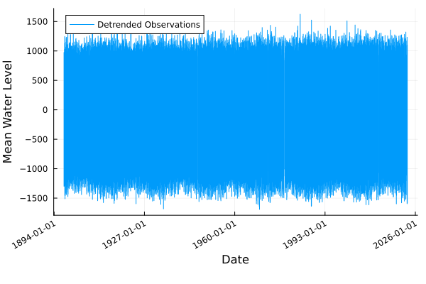

```julia
@df dat_ma plot(:datetime, :residual, label="Detrended Observations", bottom_margin=9mm)
xaxis!("Date", xrot=30)
yaxis!("Mean Water Level")
```

## Block Maxima and Generalized Extreme Value Distributions

In this section, we will use the block maxima approach and fit a Generalized Extreme Value distribution to yearly maxima.

First, we need to compute the block maxima by grouping data together by year and finding the maximum. We can do this using the `groupby`, `transform`, and `combine` functions from `DataFrames.jl`, as below.

```
In [164]:
```

```julia
dat_ma = dropmissing(dat_ma) # drop missing data
dat_annmax = combine(dat_ma -> dat_ma[argmax(dat_ma.residual), :], groupby(transform(dat_ma, :datetime => x->year.(x)), :datetime_function))
delete!(dat_annmax, nrow(dat_annmax)) # delete 2023; haven't seen much of that year yet
```

126×3 DataFrame

101 rows omitted

| Row | datetime_function Int64 | datetime DateTime | residual Float64 |
| --- | --- | --- | --- |
| 1 | 1897 | 1897-11-24T18:00:00 | 1247.5 |
| 2 | 1898 | 1898-12-12T18:00:00 | 1237.02 |
| 3 | 1899 | 1899-01-10T18:00:00 | 1471.5 |
| 4 | 1900 | 1900-01-02T19:00:00 | 1276.62 |
| 5 | 1901 | 1901-01-03T18:00:00 | 1282.43 |
| 6 | 1902 | 1902-01-23T19:00:00 | 1165.63 |
| 7 | 1903 | 1903-01-13T19:00:00 | 1180.59 |
| 8 | 1904 | 1904-12-30T14:00:00 | 1221.89 |
| 9 | 1905 | 1905-11-27T19:00:00 | 1240.64 |
| 10 | 1906 | 1906-12-16T19:00:00 | 1175.34 |
| 11 | 1907 | 1907-12-06T20:00:00 | 1295.24 |
| 12 | 1908 | 1908-02-02T19:00:00 | 1360.57 |
| 13 | 1909 | 1909-01-21T18:00:00 | 1216.81 |
| ⋮ | ⋮ | ⋮ | ⋮ |
| 115 | 2011 | 2011-05-18T07:00:00 | 1348.5 |
| 116 | 2012 | 2012-12-12T18:00:00 | 1298.43 |
| 117 | 2013 | 2013-06-24T07:00:00 | 1303.97 |
| 118 | 2014 | 2014-12-03T17:00:00 | 1264.41 |
| 119 | 2015 | 2015-11-24T18:00:00 | 1256.0 |
| 120 | 2016 | 2016-12-15T20:00:00 | 1355.96 |
| 121 | 2017 | 2017-05-26T07:00:00 | 1261.74 |
| 122 | 2018 | 2018-06-15T08:00:00 | 1273.0 |
| 123 | 2019 | 2019-12-22T16:00:00 | 1251.56 |
| 124 | 2020 | 2020-12-13T18:00:00 | 1273.07 |
| 125 | 2021 | 2021-06-23T05:00:00 | 1227.76 |
| 126 | 2022 | 2022-07-13T06:00:00 | 1320.36 |

We can use a histogram to see the distribution of the annual maxima.

```
In [165]:
```

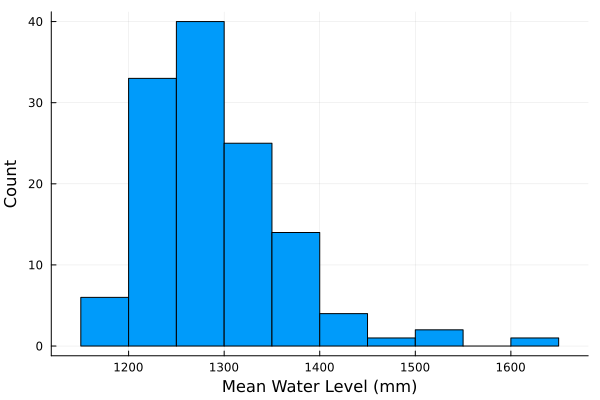

```julia
histogram(dat_annmax.residual, label=false)
ylabel!("Count")
xlabel!("Mean Water Level (mm)")
```

Next, let’s fit a GEV model to the annual maxima using `Turing.jl`.

```
In [166]:
```

```julia
@model function gev_annmax(y)
    ## pick priors
    μ ~ Normal(1000, 100) # location
    σ ~ truncated(Normal(0, 100); lower=0) # scale
    ξ ~ Normal(0, 0.5) # shape; pay special attention to this one, and you may need to experiment

    ## likelihood
    y ~ GeneralizedExtremeValue(μ, σ, ξ)
end
```

```
gev_annmax (generic function with 2 methods)
```

```
In [167]:
```

```julia
gev_model = gev_annmax(dat_annmax.residual)
n_chains = 4 # use 4 chains for Gelman-Rubin diagnostics and convergence checks
n_per_chain = 5000 # 5000 iterations per chain
gev_chain = sample(gev_model, NUTS(), MCMCThreads(), n_per_chain, n_chains; drop_warmup=true)
```

[output not shown]

```
Chains MCMC chain (5000×15×4 Array{Float64, 3}):
Iterations        = 1001:1:6000
Number of chains  = 4
Samples per chain = 5000
Wall duration     = 8.1 seconds
Compute duration  = 7.93 seconds
parameters        = μ, σ, ξ
internals         = lp, n_steps, is_accept, acceptance_rate, log_density, hamiltonian_energy, hamiltonian_energy_error, max_hamiltonian_energy_error, tree_depth, numerical_error, step_size, nom_step_size
Summary Statistics
  parameters        mean       std      mcse     ess_bulk     ess_tail      rh ⋯
      Symbol     Float64   Float64   Float64      Float64      Float64   Float ⋯
           μ   1257.7639    5.6637    0.0494   13147.8065   13991.9971    1.00 ⋯
           σ     57.2386    4.2788    0.0382   12583.3600   11984.5344    1.00 ⋯
           ξ      0.0290    0.0623    0.0008    6066.0229    6280.7822    1.00 ⋯
                                                               2 columns omitted
Quantiles
  parameters        2.5%       25.0%       50.0%       75.0%       97.5%
      Symbol     Float64     Float64     Float64     Float64     Float64
           μ   1246.7786   1253.9262   1257.7238   1261.5028   1268.9656
           σ     49.4607     54.2715     57.0195     60.0124     66.0568
           ξ     -0.0820     -0.0145      0.0251      0.0680      0.1623
```

Plotting the chains:

```
In [186]:
```

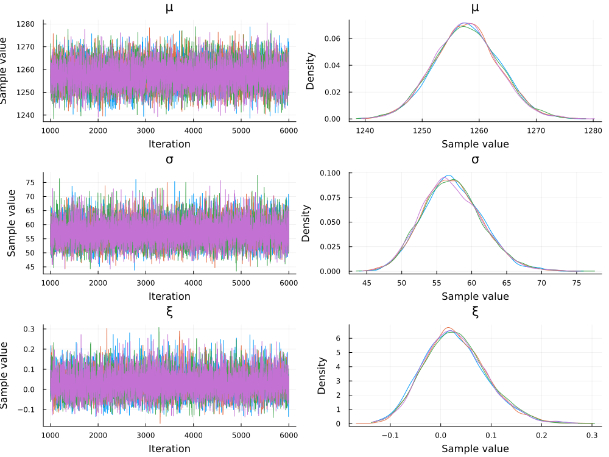

Figure 4: Traceplots (left) and marginal distributions (right) from the MCMC sampler for the GEV model.

```julia
plot(gev_chain)
```

It looks like all of the chains have converged to the same distribution; the Gelman-Rubin diagnostic is also close to 1 for all parameters.

```
In [169]:
```

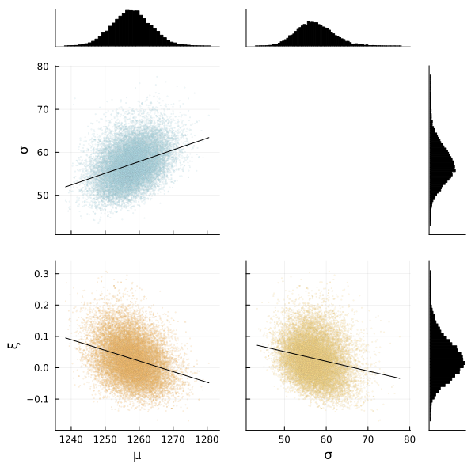

Figure 5: Corner plot for the GEV model.

```julia
corner(gev_chain)
```

We often want to quantify uncertainty in return levels by computing the associated quantile for the GEV distribution associated with each chain member (or a large enough subset). Recall that the $m$-year return level for an annual extreme model is the $1-1/m$ quantile. This will give us the return level for the detrended data, but we would need to add back in the trend to estimate return levels for the observed mean water level.

For example, e posterior predictive distribution of 100-year and 500-year return levels:

```
In [170]:
```

```julia
n_subsample = 1000
gev_posterior_samples = Array(gev_chain)
sample_idx = rand(1:size(gev_posterior_samples, 1), n_subsample)
gev_subsamples = gev_posterior_samples[sample_idx, :]
get_gev_rl(params, rp) = quantile(GeneralizedExtremeValue(params[1], params[2], params[3]), 1 - 1/rp)

rl_100 = get_gev_rl.(eachrow(gev_subsamples), 100)
rl_500 = get_gev_rl.(eachrow(gev_subsamples), 500)
```

```
1000-element Vector{Float64}:
 1660.546696795566
 1583.9341097284118
 1814.0228913479987
 1695.1670563474863
 1584.1757744152058
 1579.9089949730228
 1641.1195970388708
 1577.3558610121866
 1617.8852903939985
 1608.4611633536747
    ⋮
 1691.1970156450725
 1621.7307462706087
 1587.9099909771137
 1574.459078690208
 1528.4940898719533
 1832.4062745739816
 1630.9290819381247
 1571.0817312422641
 1685.4032288728727
```

```
In [171]:
```

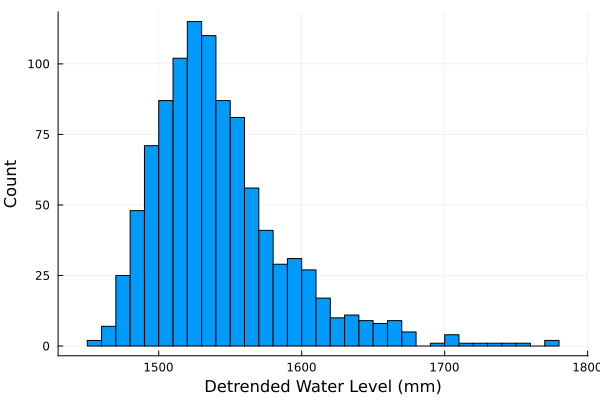

(a) 100-year return levels

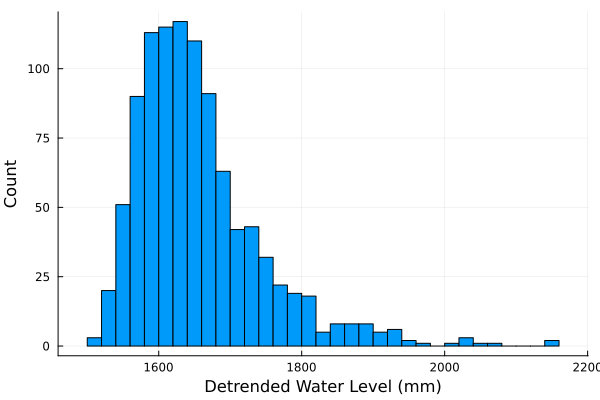

(b) 500-year return levels

Figure 6: Posterior predictive distributions for the return levels of an annual block maxima model for the San Franscisco tide gauge data.

```
In [172]:
```

```julia
p_100 = histogram(rl_100, label=false, ylabel="Count", xlabel="Detrended Water Level (mm)")
display(p_100)

p_500 = histogram(rl_500, label=false, ylabel="Count", xlabel="Detrended Water Level (mm)")
display(p_500)
```

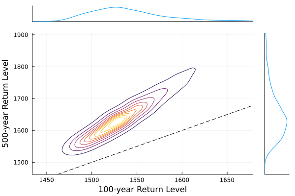

Figure 7: Density plots of the posterior predictive distributions for the 100-year and 500-year return levels. The dashed black line is a 1:1 line. The marginal distributions are plotted in the margins.

```julia
marginalkde(rl_100, rl_500, xlabel="100-year Return Level", ylabel="500-year Return Level")
Plots.abline!(1, 0, subplot=2, linestyle=:dash, color=:black)
```

## Peaks over Thresholds

In this section, we will use a Poisson Process-Generalized Pareto model to look at exceedances over a given threshold.

Let’s use a threshold based on the 99% quantile of the data. Notice that this is not quite a decision-relevant quantity due to the detrending.

```
In [173]:
```

```julia
threshold = quantile(dat_ma.residual, 0.99) # set your own threshold here
```

```
1007.206948228882
```

```
In [174]:
```

```julia
dat_exceed = dat_ma[dat_ma.residual .> threshold, :]
```

10893×2 DataFrame

10868 rows omitted

| Row | datetime DateTime | residual Float64 |
| --- | --- | --- |
| 1 | 1897-09-30T22:00:00 | 1031.29 |
| 2 | 1897-10-26T19:00:00 | 1094.51 |
| 3 | 1897-10-27T19:00:00 | 1098.25 |
| 4 | 1897-10-27T20:00:00 | 1130.32 |
| 5 | 1897-10-28T20:00:00 | 1073.31 |
| 6 | 1897-10-28T21:00:00 | 1074.89 |
| 7 | 1897-11-22T17:00:00 | 1102.07 |
| 8 | 1897-11-22T18:00:00 | 1010.74 |
| 9 | 1897-11-23T17:00:00 | 1128.33 |
| 10 | 1897-11-23T18:00:00 | 1189.99 |
| 11 | 1897-11-24T17:00:00 | 1062.84 |
| 12 | 1897-11-24T18:00:00 | 1247.5 |
| 13 | 1897-11-24T19:00:00 | 1216.83 |
| ⋮ | ⋮ | ⋮ |
| 10882 | 2022-12-22T18:00:00 | 1193.95 |
| 10883 | 2022-12-23T17:00:00 | 1045.87 |
| 10884 | 2022-12-23T18:00:00 | 1232.68 |
| 10885 | 2022-12-23T19:00:00 | 1203.17 |
| 10886 | 2023-01-19T17:00:00 | 1025.78 |
| 10887 | 2023-01-20T17:00:00 | 1096.9 |
| 10888 | 2023-01-20T18:00:00 | 1064.73 |
| 10889 | 2023-01-21T18:00:00 | 1094.11 |
| 10890 | 2023-01-21T19:00:00 | 1045.25 |
| 10891 | 2023-01-22T19:00:00 | 1102.61 |
| 10892 | 2023-01-22T20:00:00 | 1022.11 |
| 10893 | 2023-01-23T20:00:00 | 1034.76 |

Next, we need to decluster the exceedances. The code below will decluster the exceedances by taking the maximum of any exceedances that occur within a three-day period (which is both generous and was arbitrarily-chosen). Another approach is to compute the inverse of the **extremal index**, which computes the ratio of consecutive runs of exceedances versus the total number of exceedances (for more details, see Smith & Weissman (1994)).

```
In [175]:
```

```julia
function assign_cluster(dat, period)
    cluster_index = 1
    clusters = zeros(Int, length(dat))
    for i in 1:length(dat)
        if clusters[i] == 0
            clusters[findall(abs.(dat .- dat[i]) .<= period)] .= cluster_index
            cluster_index += 1
        end
    end
    return clusters
end

dat_exceed = @transform dat_exceed :cluster = assign_cluster(:datetime, Dates.Day(3))
dat_decluster = combine(dat_exceed -> dat_exceed[argmax(dat_exceed.residual), :], groupby(dat_exceed, :cluster))
```

2601×3 DataFrame

2576 rows omitted

| Row | cluster Int64 | datetime DateTime | residual Float64 |
| --- | --- | --- | --- |
| 1 | 1 | 1897-09-30T22:00:00 | 1031.29 |
| 2 | 2 | 1897-10-27T20:00:00 | 1130.32 |
| 3 | 3 | 1897-11-22T17:00:00 | 1102.07 |
| 4 | 4 | 1897-11-24T18:00:00 | 1247.5 |
| 5 | 5 | 1897-12-20T16:00:00 | 1050.69 |
| 6 | 6 | 1897-12-23T18:00:00 | 1233.08 |
| 7 | 7 | 1898-01-18T15:00:00 | 1049.75 |
| 8 | 8 | 1898-01-21T18:00:00 | 1148.97 |
| 9 | 9 | 1898-04-09T08:00:00 | 1028.56 |
| 10 | 10 | 1898-05-05T06:00:00 | 1019.33 |
| 11 | 11 | 1898-05-08T08:00:00 | 1066.96 |
| 12 | 12 | 1898-06-04T06:00:00 | 1149.53 |
| 13 | 13 | 1898-06-05T07:00:00 | 1210.85 |
| ⋮ | ⋮ | ⋮ | ⋮ |
| 2590 | 2590 | 2022-06-12T05:00:00 | 1085.87 |
| 2591 | 2591 | 2022-06-15T07:00:00 | 1212.85 |
| 2592 | 2592 | 2022-07-11T04:00:00 | 1137.56 |
| 2593 | 2593 | 2022-07-13T06:00:00 | 1320.36 |
| 2594 | 2594 | 2022-08-09T04:00:00 | 1078.81 |
| 2595 | 2595 | 2022-08-11T06:00:00 | 1166.67 |
| 2596 | 2596 | 2022-09-09T06:00:00 | 1091.35 |
| 2597 | 2597 | 2022-11-22T18:00:00 | 1031.59 |
| 2598 | 2598 | 2022-11-24T19:00:00 | 1171.01 |
| 2599 | 2599 | 2022-12-23T18:00:00 | 1232.68 |
| 2600 | 2600 | 2023-01-19T17:00:00 | 1025.78 |
| 2601 | 2601 | 2023-01-22T19:00:00 | 1102.61 |

Finally, we can make a histogram of the exceedances. Remember that we ultimately want to fit a distribution of the exceedances over the threshold (if the threshold is $u$, $\mathbb{P}(y) = \{X > u + y | X > u\}$), so we want to subtract off the threshold before making the histogram.

```
In [176]:
```

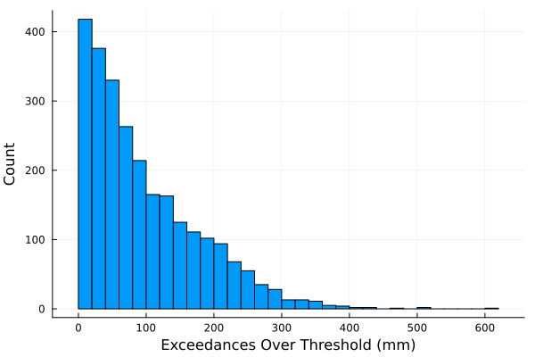

Figure 8: Histogram of exceedances over the 99% threshold.

```julia
histogram(dat_decluster.residual .- threshold, label=:false, xlabel="Exceedances Over Threshold (mm)", ylabel="Count")
```

Next, we fit a Poisson Process-Generalized Pareto model to the threshold exceedances using `Turing.jl`. As before, we will use relatively uninformative priors. The key difference is that we need to pass in counts to fit the Poisson process, so we compute those first.

```
In [177]:
```

```julia
dat_decluster = @transform dat_decluster :year = Dates.year.(dat_decluster.datetime)
counts = combine(groupby(dat_decluster, :year), nrow => :count)
delete!(counts, nrow(counts)) # including 2023 will bias the count estimate
```

126×2 DataFrame

101 rows omitted

| Row | year Int64 | count Int64 |
| --- | --- | --- |
| 1 | 1897 | 6 |
| 2 | 1898 | 15 |
| 3 | 1899 | 19 |
| 4 | 1900 | 16 |
| 5 | 1901 | 19 |
| 6 | 1902 | 12 |
| 7 | 1903 | 11 |
| 8 | 1904 | 15 |
| 9 | 1905 | 15 |
| 10 | 1906 | 18 |
| 11 | 1907 | 17 |
| 12 | 1908 | 19 |
| 13 | 1909 | 19 |
| ⋮ | ⋮ | ⋮ |
| 115 | 2011 | 25 |
| 116 | 2012 | 21 |
| 117 | 2013 | 19 |
| 118 | 2014 | 19 |
| 119 | 2015 | 24 |
| 120 | 2016 | 22 |
| 121 | 2017 | 16 |
| 122 | 2018 | 20 |
| 123 | 2019 | 24 |
| 124 | 2020 | 24 |
| 125 | 2021 | 23 |
| 126 | 2022 | 20 |

```
In [178]:
```

```julia
@model function gp_pot(y, counts)
    ## priors
    λ ~ Gamma(7.5, 1) # poisson rate (number of exceedances/yr)
    σ ~ truncated(Normal(0, 100); lower=0) # Generalized Pareto scale
    ξ ~ Normal(0, 1) # Generalized Pareto shape

    ## likelihood
    counts ~ Poisson(λ)
    y ~ GeneralizedPareto(σ, ξ)
end
```

```
gp_pot (generic function with 2 methods)
```

```
In [179]:
```

```julia
pot_model = gp_pot(dat_decluster.residual .- threshold, counts.count)
n_per_chain = 5000
n_chain = 4
pot_chain = sample(pot_model, NUTS(), MCMCThreads(), n_per_chain, n_chain; drop_warmup=true)
```

[output not shown]

```
Chains MCMC chain (5000×15×4 Array{Float64, 3}):
Iterations        = 1001:1:6000
Number of chains  = 4
Samples per chain = 5000
Wall duration     = 21.84 seconds
Compute duration  = 21.74 seconds
parameters        = λ, σ, ξ
internals         = lp, n_steps, is_accept, acceptance_rate, log_density, hamiltonian_energy, hamiltonian_energy_error, max_hamiltonian_energy_error, tree_depth, numerical_error, step_size, nom_step_size
Summary Statistics
  parameters       mean       std      mcse     ess_bulk     ess_tail      rha ⋯
      Symbol    Float64   Float64   Float64      Float64      Float64   Float6 ⋯
           λ    20.5254    0.4008    0.0036   12568.4871   12430.7093    1.000 ⋯
           σ   111.6318    2.4906    0.0262    9034.2136    9416.2721    1.001 ⋯
           ξ    -0.1569    0.0113    0.0001    8514.0118    9884.6786    1.000 ⋯
                                                               2 columns omitted
Quantiles
  parameters       2.5%      25.0%      50.0%      75.0%      97.5%
      Symbol    Float64    Float64    Float64    Float64    Float64
           λ    19.7548    20.2509    20.5211    20.7980    21.3219
           σ   106.7509   109.9599   111.6185   113.3217   116.4833
           ξ    -0.1763    -0.1651    -0.1578    -0.1499    -0.1324
```

```
In [180]:
```

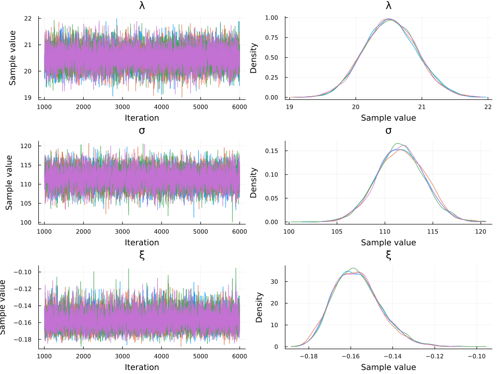

```julia
plot(pot_chain)
```

```
In [181]:
```

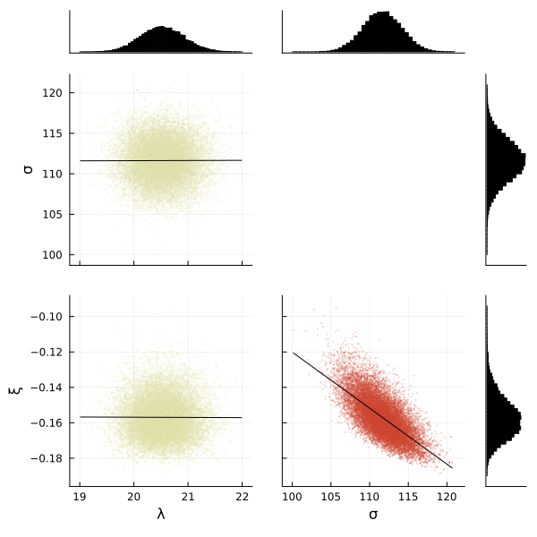

```julia
corner(pot_chain)
```

Now let’s quantify uncertainty in the 100 and 500 return levels. Due to the compound nature of the exceedance distribution, we don’t have a simple `quantile` function from `Distributions.jl`, as we did in Problem 1.3. However, we can solve the quantile equation:
$$1 - 1/m = \begin{cases}1 - \lambda \left[1 + \xi\left(\frac{x-u}{\sigma}\right)^{-1/\xi}\right] & \xi \neq 0 \\
1 - \lambda \exp\left(-\frac{x-u}{\sigma}\right) & \xi = 0\end{cases},$$
where $u$ is the threshold.

The function below finds the solution to this equation.

```
In [182]:
```

```julia
# This computes the return peroid
function return_level_pot(λ, σ, ξ, m)
    if ξ == 0
        rl = σ * log(m * λ)
    else
        rl = σ/ξ * ((m * λ)^ξ - 1)
    end
    return rl
end
```

```
return_level_pot (generic function with 1 method)
```

```
In [183]:
```

```julia
n_subsample = 1000
gpd_posterior_samples = Array(pot_chain)
sample_idx = rand(1:size(gpd_posterior_samples, 1), n_subsample)
gpd_subsamples = gev_posterior_samples[sample_idx, :]
get_gpd_rl(params, rp) = return_level_pot(params[1], params[2], params[3], rp)

rl_100 = get_gpd_rl.(eachrow(gpd_subsamples), 100) .+ threshold
rl_500 = get_gpd_rl.(eachrow(gpd_subsamples), 500) .+ threshold
```

```
1000-element Vector{Float64}:
 1986.4614784440823
 1704.1141118945652
 1885.5618417226863
 2082.5312136015145
 1884.076317430919
 2014.245206100533
 1726.10117465275
 2001.5709638295693
 1793.7734968324658
 3178.0697305062936
    ⋮
 2282.4334972194806
 2910.81111540224
 1628.522451410713
 1726.8695425900887
 2225.918525543375
 1700.0921460444438
 1641.011909626239
 5956.519470833804
 2111.4274196234833
```

```
In [184]:
```

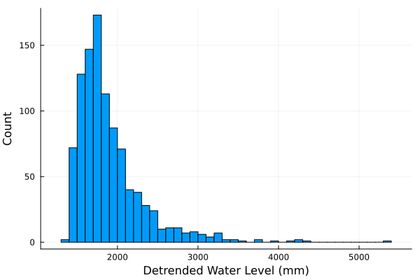

(a) 100-year return levels

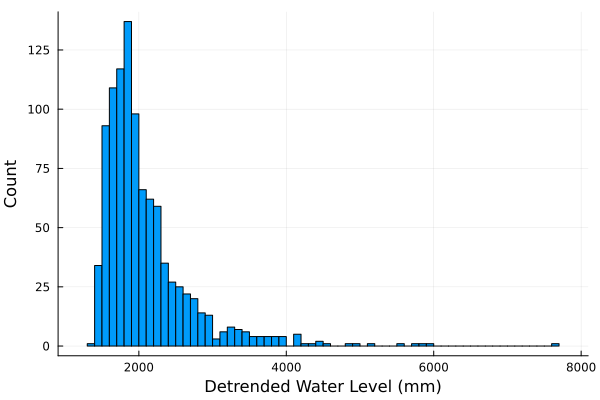

(b) 500-year return levels

Figure 9: Posterior predictive distributions for the return levels of an peaks over threshold model for the San Franscisco tide gauge data.

```
In [185]:
```

```julia
p_100 = histogram(rl_100, label=false, ylabel="Count", xlabel="Detrended Water Level (mm)")
display(p_100)

p_500 = histogram(rl_500, label=false, ylabel="Count", xlabel="Detrended Water Level (mm)")
display(p_500)
```

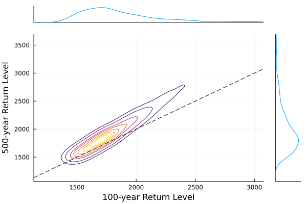

Figure 10: Density plots of the posterior predictive distributions for the 100-year and 500-year return levels. The dashed black line is a 1:1 line. The marginal distributions are plotted in the margins.

```julia
marginalkde(rl_100, rl_500, xlabel="100-year Return Level", ylabel="500-year Return Level")
Plots.abline!(1, 0, subplot=2, linestyle=:dash, color=:black)
```

Arns, A., Wahl, T., Haigh, I. D., Jensen, J., & Pattiaratchi, C. (2013). Estimating extreme water level probabilities: A comparison of the direct methods and recommendations for best practise. *Coast. Eng.*, *81*, 51–66. https://doi.org/10.1016/j.coastaleng.2013.07.003

Caldwell, P. C., Merrifield, M. A., & Thompson, P. R. (2015). Sea level measured by tide gauges from global oceans — the joint archive for sea level holdings (NCEI accession 0019568). NOAA National Centers for Environmental Information (NCEI). https://doi.org/10.7289/V5V40S7W

Smith, R. L., & Weissman, I. (1994). Estimating the extremal index. *J. R. Stat. Soc. Series B Stat. Methodol.*, *56*(3), 515–528.